# R Mark Enaho

```r
library(dplyr)
library(readxl)
#library(normtest)
library(stargazer)
library(ggplot2)
```

# Descarga de Data

```r
edu <-"https://raw.githubusercontent.com/dereckamesquita/Learning-Before-Estadistica/main/Enaho/Data_Enaho/educacion.csv"
sal<-"https://raw.githubusercontent.com/dereckamesquita/Learning-Before-Estadistica/main/Enaho/Data_Enaho/salud.csv"
iyl<-"https://raw.githubusercontent.com/dereckamesquita/Learning-Before-Estadistica/main/Enaho/Data_Enaho/ingresosylaboral.csv"
dedu <- read.csv(edu)
dsal<- read.csv(sal)
diyl<- read.csv(iyl)
```

## Unión de las bases de datos

Especificamos que la unión se hace en la columna llamada “MES” la cual contiene un id único. Tambien elimanos los valores ausentes.

```r
datafull<-full_join(dedu,diyl,by="MES")
data<-na.omit(datafull)
```

En este caso, con fines especificos limpiamos la data de acuerdo a lo que necesitamos.

```r
datafull1<-full_join(data,dsal,by="MES")
data1<-na.omit(datafull1)
data1$P524A1[data1$P524A1=="999999"]=NA

data1$P301A[data1$P301A=="Básica especial"]=NA
data1 <- na.omit(data1)
```

## Exportar data

```r
write.csv(data1, file="data.csv")
```

## Llamando a la nueva data

```r
data1<-read.csv(file ="data.csv", header=T )
```

# Procesando la data

## Asignando niveles a las variables

Usaremos un bucle for, que recorra los numeros 1 y 2 para cambiar los valores por un string denominado segun el sexo. Usamos “model.matrix” para tener el formato necesario que requieren las regresiónes categoricas.

```r
P207 <- c("Hombre","Mujer")
#Forma 1
for (a in (1:2)){
  data1$P207[data1$P207==a]=P207[a]
}

data1$P207<- factor(data1$P207,levels =P207)
modelP207<- model.matrix(data1$P524A1~data1$P207+data1$P513T)
```

```r
P300A <- c("Quechua","Aimara","Otra lengua nativa","Castellano",
          "Portugués","Otra lengua extranjera","No escucha/no habla","Lengua de señas peruanas","Ashaninka","Awajún","Shipibo","Shawi","Matsigenka","Achuar")

#Forma 1
for (a in (1:15)){
  data1$P300A[data1$P300A==a]=P300A[a]
}
data1$P300A<- factor(data1$P300A,levels =P300A)
modelP300A<- model.matrix(data1$P524A1~data1$P207+data1$P300A)
```

```r
P301A <- c("Sin nivel","Educación inicial","Primaria incompleta","Primaria completa",
          "Secundaria incompleta","Secundaria completa","Superior no universitaria Incompleta","Superior no universitaria completa","Superior universitaria completa","Maestria/Doctorado","Básica especial")

#Forma 1
for (a in (1:12)){
  data1$P301A[data1$P301A==a]=P301A[a]
}

#Limpieza de Educacion Basica
data1$P301A[data1$P301A=="Básica especial"]=NA
data1$P301A[data1$P301A=="Sin nivel"]=NA

data1 <- na.omit(data1)
#Niveles
data1$P301A<- factor(data1$P301A,levels =P301A)
modelP301A<- model.matrix(data1$P524A1~data1$P301A+data1$P207)

#head(modelP301A[,-1])
```

```r
#Cambiamos todos los 2 por el numero 0.
data1$P401H1[data1$P401H1==2]=0
data1$P401H2[data1$P401H2==2]=0
data1$P401H3[data1$P401H3==2]=0
data1$P401H4[data1$P401H4==2]=0
data1$P401H5[data1$P401H5==2]=0
data1$P401H6[data1$P401H6==2]=0
#Creamos una columna con el total de los que tienen limitaciones

data1$P401HT <- data1$P401H1+data1$P401H2+data1$P401H3+data1$P401H4+data1$P401H5+data1$P401H6

data1$P401HT <- data1$P401HT+1

#Categorizamos

P401HT <- c("Sano","Una_limitacion","Dos_limitacion","Tres_limitacion","Cuatro_limitacion")

#Forma 1
for (a in (1:5)){
  data1$P401HT[data1$P401HT==a]=P401HT [a]
}

data1$P401HT <- factor(data1$P401HT ,levels =P401HT )
```

```r
#Renombrando DOMINIO
names(data1)[names(data1) == 'DOMINIO.x'] <- 'DOMINIO'

data1$DOMINIO <- as.numeric(data1$DOMINIO)

str(data1$DOMINIO)
```

```
 num [1:4975] 4 4 4 4 7 7 7 7 7 7 ...
```

```r
Dominios1 <- c("CostaNorte", "CostaCentro", "CostaSur","SierraNorte","SierraCentro","SierraSur","Selva", "LimaMetropolitana")

Dominios <- c("CN", "CC", "CS","SN","SC","SS","SE", "LM")
#Cambiamos numeros
for (a in (1:8)){
  data1$DOMINIO[data1$DOMINIO==a]=Dominios[a]
}

data1$DOMINIO<- factor(data1$DOMINIO,levels =Dominios)
```

# Primeros graficos

Creamos un grafico que relacione los dominio

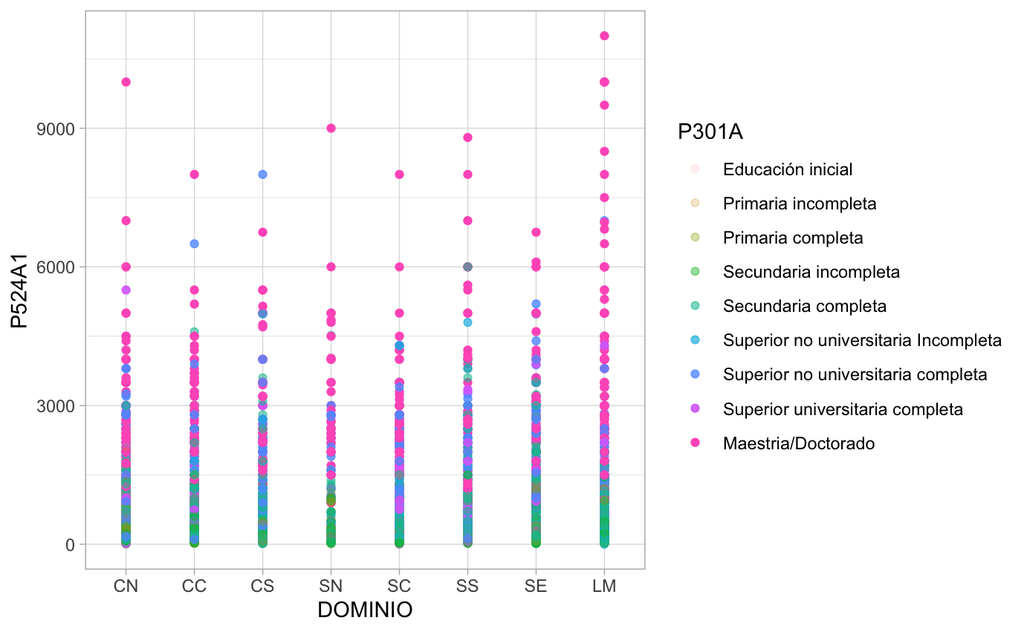

```r
data1$P524A1=as.numeric(data1$P524A1)
ggplot(data1, aes(x=DOMINIO, y=P524A1, color=P301A, alpha=P301A)) +
  geom_point() + theme_light()
```

```r
mod1 <- lm(P524A1 ~ DOMINIO ,data=data1)
summary(mod1)
```

```
Call:
lm(formula = P524A1 ~ DOMINIO, data = data1)

Residuals:
    Min      1Q  Median      3Q     Max
-1280.6  -765.7  -387.7   406.9  9719.4

Coefficients:
            Estimate Std. Error t value Pr(>|t|)
(Intercept)   955.41      37.86  25.238  < 2e-16 ***
DOMINIOCC     -69.75      59.35  -1.175   0.2400
DOMINIOCS     285.01      71.04   4.012 6.11e-05 ***
DOMINIOSN      84.85      89.52   0.948   0.3433
DOMINIOSC      25.37      60.71   0.418   0.6760
DOMINIOSS     137.73      61.71   2.232   0.0257 *
DOMINIOSE     -67.74      52.67  -1.286   0.1985
DOMINIOLM     325.20      57.14   5.691 1.33e-08 ***
---
Signif. codes:  0 ‘***’ 0.001 ‘**’ 0.01 ‘*’ 0.05 ‘.’ 0.1 ‘ ’ 1

Residual standard error: 1150 on 4967 degrees of freedom
Multiple R-squared:  0.01548,   Adjusted R-squared:  0.01409
F-statistic: 11.15 on 7 and 4967 DF,  p-value: 4.427e-14
```

```r
stargazer(mod1, type="text")
```

```
===============================================
                        Dependent variable:
                    ---------------------------
                              P524A1
-----------------------------------------------
DOMINIOCC                     -69.745
                             (59.351)

DOMINIOCS                   285.008***
                             (71.041)

DOMINIOSN                     84.846
                             (89.518)

DOMINIOSC                     25.373
                             (60.715)

DOMINIOSS                    137.727**
                             (61.706)

DOMINIOSE                     -67.741
                             (52.673)

DOMINIOLM                   325.198***
                             (57.140)

Constant                    955.407***
                             (37.855)

-----------------------------------------------
Observations                   4,975
R2                             0.015
Adjusted R2                    0.014
Residual Std. Error    1,150.077 (df = 4967)
F Statistic          11.154*** (df = 7; 4967)
===============================================
Note:               *p<0.1; **p<0.05; ***p<0.01
```

```r
mod <- lm(P524A1 ~ P301A
          , data=data1)

summary(mod)
```

[output not shown]

[figure not shown]

```r
ggplot(data1, aes(x=P207, y=P524A1, color=P301A)) +
  geom_point() + theme_light()
```

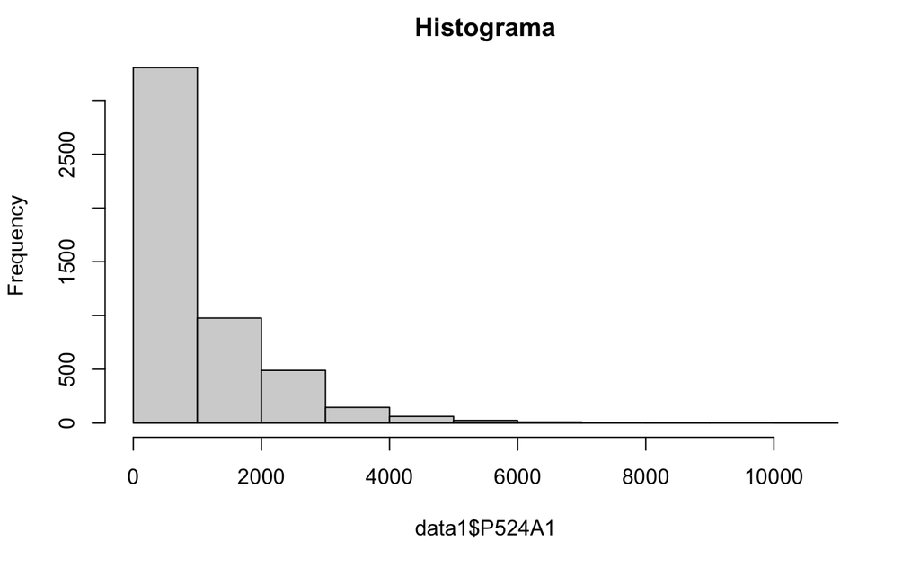

```r
hist(data1$P524A1, main="Histograma")
```